# Still Light Years Ahead? - Is the Golden State Warriors' Dynasty Over?

### CMSC320 Final Tutorial | by Shreyes Varde

## Motivation

Yet 2019 was a far cry from the success that the Warriors had enjoyed for the past half-decade. Durant left to another team, and Stephen Curry and Klay Thompson suffered season-ending injuries. In 2020, Curry returned, but his individual brilliance was not enough to lift a mediocre roster and they missed the playoffs. It seemed as if the Warriors' run was over, and [many talking heads on TV belabored this point](https://www.youtube.com/watch?v=bDU6VZCEJXc).

However, the Warriors were not done yet. In 2022, they came back with a vengeance, starting 18-2 in their first 20 games. Injuries to key players hurt them along the way, but they entered the playoffs as the 3rd seed in the West, eventually making it to the NBA Finals where they beat the Boston Celtics in 6 games. This made the overall count now 4 finals in 8 years, not to mention 6 total appearances. It was clear this was the next dynasty of NBA history, one up there with the very best.

Yet the past two years have not been kind to the Warriors. In 2022-23, they lost in the second round of the playoffs after a hard fought win in 7 games over the upstart Sacramento Kings. In 2023-24, they didn't even make the playoffs, losing to those very Kings in the play-in games. With the core players getting older and the league getting more competitive, much has been said about this being the end of the Warriors dynasty.

- Article by CBS Sports [(here)](https://www.cbssports.com/nba/news/warriors-legendary-aging-dynasty-may-have-finally-received-death-blow-in-humiliating-play-in-loss-to-kings/)
- Article by The Athletic [(here)](https://theathletic.com/5423748/2024/04/17/warriors-dynasty-run-end-nba-game-changing/)
- Article by The Mercury News [(here)](https://www.mercurynews.com/2024/04/17/kurtenbach-the-warriors-dynasty-is-over-it-ended-in-embarrassment/)

But is is really the end? And if it is, how can the Warriors get back to their glory days? To investigate this, I took a data-driven approach towards analyzing three different causes:

- Has Stephen Curry declined?
- Is the support from the complementary players not as strong?
- Is Coach Steve Kerr still at the top of his game?

My objective is to use data, modeling, and statistics to see if any of these reasons have significant statistical backing, and we hope you (the reader) are able to learn more about analyzing data through Python, proving or disproving claims using statistics, while also gaining a better understanding of how data science can be applied to contexts such as basketball and sports.

## Data Collection

### Dataset 1

first, we need data regarding Steph Curry. I retrieved Stephen Curry's career stats through [Basketball Reference](https://www.basketball-reference.com/players/c/curryst01.html#all_per_game-playoffs_per_game). This dataset contains various stats of his throughout his 15 year career. This specific table refers to the regular seasons of the NBA, so discounting any playoff games.

```python
import numpy as np
import pandas as pd
```

```python
# read in csv into dataframe using pandas' "read_csv" function
steph_df = pd.read_csv("steph.csv")
steph_df
```

|  | Season | Age | Tm | Lg | Pos | G | GS | MP | FG | FGA | ... | ORB | DRB | TRB | AST | STL | BLK | TOV | PF | PTS | Awards |
| --- | --- | --- | --- | --- | --- | --- | --- | --- | --- | --- | --- | --- | --- | --- | --- | --- | --- | --- | --- | --- | --- |
| 0 | 2009-10 | 21.0 | GSW | NBA | PG | 80 | 77 | 36.2 | 6.6 | 14.3 | ... | 0.6 | 3.9 | 4.5 | 5.9 | 1.9 | 0.2 | 3.0 | 3.2 | 17.5 | ROY-2 |
| 1 | 2010-11 | 22.0 | GSW | NBA | PG | 74 | 74 | 33.6 | 6.8 | 14.2 | ... | 0.7 | 3.2 | 3.9 | 5.8 | 1.5 | 0.3 | 3.1 | 3.1 | 18.6 | NaN |
| 2 | 2011-12 | 23.0 | GSW | NBA | PG | 26 | 23 | 28.2 | 5.6 | 11.4 | ... | 0.6 | 2.8 | 3.4 | 5.3 | 1.5 | 0.3 | 2.5 | 2.4 | 14.7 | NaN |
| 3 | 2012-13 | 24.0 | GSW | NBA | PG | 78 | 78 | 38.2 | 8.0 | 17.8 | ... | 0.8 | 3.3 | 4.0 | 6.9 | 1.6 | 0.2 | 3.1 | 2.5 | 22.9 | MVP-11MIP-8 |
| 4 | 2013-14 | 25.0 | GSW | NBA | PG | 78 | 78 | 36.5 | 8.4 | 17.7 | ... | 0.6 | 3.7 | 4.3 | 8.5 | 1.6 | 0.2 | 3.8 | 2.5 | 24.0 | MVP-6NBA2AS |
| 5 | 2014-15 | 26.0 | GSW | NBA | PG | 80 | 80 | 32.7 | 8.2 | 16.8 | ... | 0.7 | 3.6 | 4.3 | 7.7 | 2.0 | 0.2 | 3.1 | 2.0 | 23.8 | MVP-1NBA1AS |
| 6 | 2015-16 | 27.0 | GSW | NBA | PG | 79 | 79 | 34.2 | 10.2 | 20.2 | ... | 0.9 | 4.6 | 5.4 | 6.7 | 2.1 | 0.2 | 3.3 | 2.0 | 30.1 | MVP-1NBA1ASMIP-4 |
| 7 | 2016-17 | 28.0 | GSW | NBA | PG | 79 | 79 | 33.4 | 8.5 | 18.3 | ... | 0.8 | 3.7 | 4.5 | 6.6 | 1.8 | 0.2 | 3.0 | 2.3 | 25.3 | MVP-6NBA2AS |
| 8 | 2017-18 | 29.0 | GSW | NBA | PG | 51 | 51 | 32.0 | 8.4 | 16.9 | ... | 0.7 | 4.4 | 5.1 | 6.1 | 1.6 | 0.2 | 3.0 | 2.2 | 26.4 | MVP-10NBA3AS |
| 9 | 2018-19 | 30.0 | GSW | NBA | PG | 69 | 69 | 33.8 | 9.2 | 19.4 | ... | 0.7 | 4.7 | 5.3 | 5.2 | 1.3 | 0.4 | 2.8 | 2.4 | 27.3 | MVP-5NBA1AS |
| 10 | 2019-20 | 31.0 | GSW | NBA | PG | 5 | 5 | 27.8 | 6.6 | 16.4 | ... | 0.8 | 4.4 | 5.2 | 6.6 | 1.0 | 0.4 | 3.2 | 2.2 | 20.8 | NaN |
| 11 | 2020-21 | 32.0 | GSW | NBA | PG | 63 | 63 | 34.2 | 10.4 | 21.7 | ... | 0.5 | 5.0 | 5.5 | 5.8 | 1.2 | 0.1 | 3.4 | 1.9 | 32.0 | MVP-3NBA1AS |
| 12 | 2021-22 | 33.0 | GSW | NBA | PG | 64 | 64 | 34.5 | 8.4 | 19.1 | ... | 0.5 | 4.7 | 5.2 | 6.3 | 1.3 | 0.4 | 3.2 | 2.0 | 25.5 | MVP-8NBA2AS |
| 13 | 2022-23 | 34.0 | GSW | NBA | PG | 56 | 56 | 34.7 | 10.0 | 20.2 | ... | 0.7 | 5.4 | 6.1 | 6.3 | 0.9 | 0.4 | 3.2 | 2.1 | 29.4 | MVP-9NBA2ASCPOY-9 |
| 14 | 2023-24 | 35.0 | GSW | NBA | PG | 74 | 74 | 32.7 | 8.8 | 19.5 | ... | 0.5 | 4.0 | 4.5 | 5.1 | 0.7 | 0.4 | 2.8 | 1.6 | 26.4 | AS |
| 15 | Career | NaN | NaN | NBA | NaN | 956 | 950 | 34.2 | 8.5 | 17.9 | ... | 0.7 | 4.1 | 4.7 | 6.4 | 1.5 | 0.2 | 3.1 | 2.3 | 24.8 | NaN |

16 rows × 31 columns

Looking at this dataframe, we see that Stephen Curry only played 5 games in the 2019-20 season, due to injury. A 5-game sample size isn't enough to glean any conclusions from, and it might actually skew our findings if we leave it in, so let's drop the row. We still have 14 other rows of data to use.

```python
steph_df.drop(index=10, inplace=True)
steph_df
```

|  | Season | Age | Tm | Lg | Pos | G | GS | MP | FG | FGA | ... | ORB | DRB | TRB | AST | STL | BLK | TOV | PF | PTS | Awards |
| --- | --- | --- | --- | --- | --- | --- | --- | --- | --- | --- | --- | --- | --- | --- | --- | --- | --- | --- | --- | --- | --- |
| 0 | 2009-10 | 21.0 | GSW | NBA | PG | 80 | 77 | 36.2 | 6.6 | 14.3 | ... | 0.6 | 3.9 | 4.5 | 5.9 | 1.9 | 0.2 | 3.0 | 3.2 | 17.5 | ROY-2 |
| 1 | 2010-11 | 22.0 | GSW | NBA | PG | 74 | 74 | 33.6 | 6.8 | 14.2 | ... | 0.7 | 3.2 | 3.9 | 5.8 | 1.5 | 0.3 | 3.1 | 3.1 | 18.6 | NaN |
| 2 | 2011-12 | 23.0 | GSW | NBA | PG | 26 | 23 | 28.2 | 5.6 | 11.4 | ... | 0.6 | 2.8 | 3.4 | 5.3 | 1.5 | 0.3 | 2.5 | 2.4 | 14.7 | NaN |
| 3 | 2012-13 | 24.0 | GSW | NBA | PG | 78 | 78 | 38.2 | 8.0 | 17.8 | ... | 0.8 | 3.3 | 4.0 | 6.9 | 1.6 | 0.2 | 3.1 | 2.5 | 22.9 | MVP-11MIP-8 |
| 4 | 2013-14 | 25.0 | GSW | NBA | PG | 78 | 78 | 36.5 | 8.4 | 17.7 | ... | 0.6 | 3.7 | 4.3 | 8.5 | 1.6 | 0.2 | 3.8 | 2.5 | 24.0 | MVP-6NBA2AS |
| 5 | 2014-15 | 26.0 | GSW | NBA | PG | 80 | 80 | 32.7 | 8.2 | 16.8 | ... | 0.7 | 3.6 | 4.3 | 7.7 | 2.0 | 0.2 | 3.1 | 2.0 | 23.8 | MVP-1NBA1AS |
| 6 | 2015-16 | 27.0 | GSW | NBA | PG | 79 | 79 | 34.2 | 10.2 | 20.2 | ... | 0.9 | 4.6 | 5.4 | 6.7 | 2.1 | 0.2 | 3.3 | 2.0 | 30.1 | MVP-1NBA1ASMIP-4 |
| 7 | 2016-17 | 28.0 | GSW | NBA | PG | 79 | 79 | 33.4 | 8.5 | 18.3 | ... | 0.8 | 3.7 | 4.5 | 6.6 | 1.8 | 0.2 | 3.0 | 2.3 | 25.3 | MVP-6NBA2AS |
| 8 | 2017-18 | 29.0 | GSW | NBA | PG | 51 | 51 | 32.0 | 8.4 | 16.9 | ... | 0.7 | 4.4 | 5.1 | 6.1 | 1.6 | 0.2 | 3.0 | 2.2 | 26.4 | MVP-10NBA3AS |
| 9 | 2018-19 | 30.0 | GSW | NBA | PG | 69 | 69 | 33.8 | 9.2 | 19.4 | ... | 0.7 | 4.7 | 5.3 | 5.2 | 1.3 | 0.4 | 2.8 | 2.4 | 27.3 | MVP-5NBA1AS |
| 11 | 2020-21 | 32.0 | GSW | NBA | PG | 63 | 63 | 34.2 | 10.4 | 21.7 | ... | 0.5 | 5.0 | 5.5 | 5.8 | 1.2 | 0.1 | 3.4 | 1.9 | 32.0 | MVP-3NBA1AS |
| 12 | 2021-22 | 33.0 | GSW | NBA | PG | 64 | 64 | 34.5 | 8.4 | 19.1 | ... | 0.5 | 4.7 | 5.2 | 6.3 | 1.3 | 0.4 | 3.2 | 2.0 | 25.5 | MVP-8NBA2AS |
| 13 | 2022-23 | 34.0 | GSW | NBA | PG | 56 | 56 | 34.7 | 10.0 | 20.2 | ... | 0.7 | 5.4 | 6.1 | 6.3 | 0.9 | 0.4 | 3.2 | 2.1 | 29.4 | MVP-9NBA2ASCPOY-9 |
| 14 | 2023-24 | 35.0 | GSW | NBA | PG | 74 | 74 | 32.7 | 8.8 | 19.5 | ... | 0.5 | 4.0 | 4.5 | 5.1 | 0.7 | 0.4 | 2.8 | 1.6 | 26.4 | AS |
| 15 | Career | NaN | NaN | NBA | NaN | 956 | 950 | 34.2 | 8.5 | 17.9 | ... | 0.7 | 4.1 | 4.7 | 6.4 | 1.5 | 0.2 | 3.1 | 2.3 | 24.8 | NaN |

15 rows × 31 columns

I'm going to keep the indices after 2019-20 as is for now because it will help in the ML section. Let's also take a look at some advanced stats. If you would like to learn more about different advanced stats, follow this [link](https://faq.stathead.com/knowledge/basketball-advanced-stats). For our purposes right now, all you need to know is that advanced stats seek to understand basketball through more objective analysis and they more accurately evaluates the skill and production of a player or team.

```python
steph_advanced = pd.read_csv("advanced_stats/steph_advanced.csv")
steph_advanced
```

|  | Season | Age | Tm | Lg | Pos | G | MP | PER | TS% | 3PAr | ... | Unnamed: 19 | OWS | DWS | WS | WS/48 | Unnamed: 24 | OBPM | DBPM | BPM | VORP |
| --- | --- | --- | --- | --- | --- | --- | --- | --- | --- | --- | --- | --- | --- | --- | --- | --- | --- | --- | --- | --- | --- |
| 0 | 2009-10 | 21.0 | GSW | NBA | PG | 80 | 2896 | 16.3 | 0.568 | 0.332 | ... | NaN | 3.0 | 1.6 | 4.7 | 0.077 | NaN | 1.1 | -0.5 | 0.7 | 2.0 |
| 1 | 2010-11 | 22.0 | GSW | NBA | PG | 74 | 2489 | 19.4 | 0.595 | 0.325 | ... | NaN | 5.4 | 1.3 | 6.6 | 0.128 | NaN | 3.0 | -0.7 | 2.3 | 2.7 |
| 2 | 2011-12 | 23.0 | GSW | NBA | PG | 26 | 732 | 21.2 | 0.605 | 0.409 | ... | NaN | 1.8 | 0.4 | 2.2 | 0.144 | NaN | 4.1 | 0.3 | 4.3 | 1.2 |
| 3 | 2012-13 | 24.0 | GSW | NBA | PG | 78 | 2983 | 21.3 | 0.589 | 0.432 | ... | NaN | 8.4 | 2.8 | 11.2 | 0.180 | NaN | 5.3 | 0.1 | 5.4 | 5.6 |
| 4 | 2013-14 | 25.0 | GSW | NBA | PG | 78 | 2846 | 24.1 | 0.610 | 0.445 | ... | NaN | 9.3 | 4.0 | 13.4 | 0.225 | NaN | 6.3 | 1.1 | 7.4 | 6.7 |
| 5 | 2014-15 | 26.0 | GSW | NBA | PG | 80 | 2613 | 28.0 | 0.638 | 0.482 | ... | NaN | 11.5 | 4.1 | 15.7 | 0.288 | NaN | 8.2 | 1.7 | 9.9 | 7.9 |
| 6 | 2015-16 | 27.0 | GSW | NBA | PG | 79 | 2700 | 31.5 | 0.669 | 0.554 | ... | NaN | 13.8 | 4.1 | 17.9 | 0.318 | NaN | 10.3 | 1.6 | 11.9 | 9.5 |
| 7 | 2016-17 | 28.0 | GSW | NBA | PG | 79 | 2638 | 24.6 | 0.624 | 0.547 | ... | NaN | 8.7 | 3.9 | 12.6 | 0.229 | NaN | 6.7 | 0.3 | 6.9 | 5.9 |
| 8 | 2017-18 | 29.0 | GSW | NBA | PG | 51 | 1631 | 28.2 | 0.675 | 0.580 | ... | NaN | 7.2 | 1.9 | 9.1 | 0.267 | NaN | 7.8 | 0.0 | 7.7 | 4.0 |
| 9 | 2018-19 | 30.0 | GSW | NBA | PG | 69 | 2331 | 24.4 | 0.641 | 0.604 | ... | NaN | 7.2 | 2.5 | 9.7 | 0.199 | NaN | 7.1 | -0.5 | 6.6 | 5.1 |
| 10 | 2019-20 | 31.0 | GSW | NBA | PG | 5 | 139 | 21.7 | 0.557 | 0.598 | ... | NaN | 0.2 | 0.1 | 0.3 | 0.103 | NaN | 4.5 | -0.6 | 3.9 | 0.2 |
| 11 | 2020-21 | 32.0 | GSW | NBA | PG | 63 | 2152 | 26.3 | 0.655 | 0.587 | ... | NaN | 6.5 | 2.5 | 9.0 | 0.201 | NaN | 8.3 | 0.4 | 8.7 | 5.8 |
| 12 | 2021-22 | 33.0 | GSW | NBA | PG | 64 | 2211 | 21.4 | 0.601 | 0.613 | ... | NaN | 4.6 | 3.4 | 8.0 | 0.173 | NaN | 5.4 | 0.4 | 5.8 | 4.4 |
| 13 | 2022-23 | 34.0 | GSW | NBA | PG | 56 | 1941 | 24.1 | 0.656 | 0.564 | ... | NaN | 5.8 | 2.0 | 7.8 | 0.192 | NaN | 7.5 | 0.1 | 7.5 | 4.7 |
| 14 | 2023-24 | 35.0 | GSW | NBA | PG | 74 | 2421 | 20.6 | 0.616 | 0.606 | ... | NaN | 5.2 | 2.0 | 7.2 | 0.142 | NaN | 6.3 | -1.1 | 5.2 | 4.4 |
| 15 | Career | NaN | NaN | NBA | NaN | 956 | 32723 | 23.6 | 0.626 | 0.515 | ... | NaN | 98.5 | 36.6 | 135.2 | 0.198 | NaN | 6.2 | 0.2 | 6.5 | 70.0 |

16 rows × 29 columns

```python
## dropping for same reasons as before
steph_advanced.drop(index=[10, 15], inplace=True)
steph_advanced
```

|  | Season | Age | Tm | Lg | Pos | G | MP | PER | TS% | 3PAr | ... | Unnamed: 19 | OWS | DWS | WS | WS/48 | Unnamed: 24 | OBPM | DBPM | BPM | VORP |
| --- | --- | --- | --- | --- | --- | --- | --- | --- | --- | --- | --- | --- | --- | --- | --- | --- | --- | --- | --- | --- | --- |
| 0 | 2009-10 | 21.0 | GSW | NBA | PG | 80 | 2896 | 16.3 | 0.568 | 0.332 | ... | NaN | 3.0 | 1.6 | 4.7 | 0.077 | NaN | 1.1 | -0.5 | 0.7 | 2.0 |
| 1 | 2010-11 | 22.0 | GSW | NBA | PG | 74 | 2489 | 19.4 | 0.595 | 0.325 | ... | NaN | 5.4 | 1.3 | 6.6 | 0.128 | NaN | 3.0 | -0.7 | 2.3 | 2.7 |
| 2 | 2011-12 | 23.0 | GSW | NBA | PG | 26 | 732 | 21.2 | 0.605 | 0.409 | ... | NaN | 1.8 | 0.4 | 2.2 | 0.144 | NaN | 4.1 | 0.3 | 4.3 | 1.2 |
| 3 | 2012-13 | 24.0 | GSW | NBA | PG | 78 | 2983 | 21.3 | 0.589 | 0.432 | ... | NaN | 8.4 | 2.8 | 11.2 | 0.180 | NaN | 5.3 | 0.1 | 5.4 | 5.6 |
| 4 | 2013-14 | 25.0 | GSW | NBA | PG | 78 | 2846 | 24.1 | 0.610 | 0.445 | ... | NaN | 9.3 | 4.0 | 13.4 | 0.225 | NaN | 6.3 | 1.1 | 7.4 | 6.7 |
| 5 | 2014-15 | 26.0 | GSW | NBA | PG | 80 | 2613 | 28.0 | 0.638 | 0.482 | ... | NaN | 11.5 | 4.1 | 15.7 | 0.288 | NaN | 8.2 | 1.7 | 9.9 | 7.9 |
| 6 | 2015-16 | 27.0 | GSW | NBA | PG | 79 | 2700 | 31.5 | 0.669 | 0.554 | ... | NaN | 13.8 | 4.1 | 17.9 | 0.318 | NaN | 10.3 | 1.6 | 11.9 | 9.5 |
| 7 | 2016-17 | 28.0 | GSW | NBA | PG | 79 | 2638 | 24.6 | 0.624 | 0.547 | ... | NaN | 8.7 | 3.9 | 12.6 | 0.229 | NaN | 6.7 | 0.3 | 6.9 | 5.9 |
| 8 | 2017-18 | 29.0 | GSW | NBA | PG | 51 | 1631 | 28.2 | 0.675 | 0.580 | ... | NaN | 7.2 | 1.9 | 9.1 | 0.267 | NaN | 7.8 | 0.0 | 7.7 | 4.0 |
| 9 | 2018-19 | 30.0 | GSW | NBA | PG | 69 | 2331 | 24.4 | 0.641 | 0.604 | ... | NaN | 7.2 | 2.5 | 9.7 | 0.199 | NaN | 7.1 | -0.5 | 6.6 | 5.1 |
| 11 | 2020-21 | 32.0 | GSW | NBA | PG | 63 | 2152 | 26.3 | 0.655 | 0.587 | ... | NaN | 6.5 | 2.5 | 9.0 | 0.201 | NaN | 8.3 | 0.4 | 8.7 | 5.8 |
| 12 | 2021-22 | 33.0 | GSW | NBA | PG | 64 | 2211 | 21.4 | 0.601 | 0.613 | ... | NaN | 4.6 | 3.4 | 8.0 | 0.173 | NaN | 5.4 | 0.4 | 5.8 | 4.4 |
| 13 | 2022-23 | 34.0 | GSW | NBA | PG | 56 | 1941 | 24.1 | 0.656 | 0.564 | ... | NaN | 5.8 | 2.0 | 7.8 | 0.192 | NaN | 7.5 | 0.1 | 7.5 | 4.7 |
| 14 | 2023-24 | 35.0 | GSW | NBA | PG | 74 | 2421 | 20.6 | 0.616 | 0.606 | ... | NaN | 5.2 | 2.0 | 7.2 | 0.142 | NaN | 6.3 | -1.1 | 5.2 | 4.4 |

14 rows × 29 columns

### Dataset 2

However, while Stephen Curry is the engine of the Warriors dynasty, we also need to analyze the players around him. The rosters for the past 10 seasons are available, once again, on Basketball Reference. It is important to note that the rosters are organized by highest-minute players to lowest-minute. A starting lineup in the NBA is made up of 5 players, so for our purposes, we are going to look at the 5 players who played the most minutes every year for the Warriors. This should give us a good idea as to the pieces around Stephen Curry.

```python
# create formatted string which we can later input year into
base_csv = "rosters/{}.csv"

others = pd.DataFrame()

# list of years for which we are looking at the rosters for
# note, excluded 2020 because Stephen Curry was injured, so not a good setup for seeing if he has help
years = [2015, 2016, 2017, 2018, 2019, 2021, 2022, 2023, 2024]

for year in years:
    # add year into file path so it can be read into csv
    csv_file = base_csv.format(year)
    df = pd.read_csv(csv_file)

    # add column of year so easier to differentiate between players
    df['year'] = year

    # only want the top 5 highest minute players and continually concatenate onto larger dataframe
    others = pd.concat([others, df[:5]])

# Stephen Curry is one of the 5 highest-minute players but we already have his data, so let's filter him out of this dataset.
others = others[others['Player'] != "Stephen Curry"]
others
```

|  | Rk | Player | Age | G | GS | MP | FG | FGA | FG% | 3P | ... | ORB | DRB | TRB | AST | STL | BLK | TOV | PF | PTS | year |
| --- | --- | --- | --- | --- | --- | --- | --- | --- | --- | --- | --- | --- | --- | --- | --- | --- | --- | --- | --- | --- | --- |
| 1 | 2 | Klay Thompson | 24 | 77 | 77 | 31.9 | 7.8 | 16.9 | 0.463 | 3.1 | ... | 0.4 | 2.9 | 3.2 | 2.9 | 1.1 | 0.8 | 1.9 | 1.6 | 21.7 | 2015 |
| 2 | 3 | Draymond Green | 24 | 79 | 79 | 31.5 | 4.3 | 9.7 | 0.443 | 1.4 | ... | 1.4 | 6.7 | 8.2 | 3.7 | 1.6 | 1.3 | 1.7 | 3.2 | 11.7 | 2015 |
| 3 | 4 | Harrison Barnes | 22 | 82 | 82 | 28.3 | 3.9 | 8.0 | 0.482 | 1.1 | ... | 1.4 | 4.1 | 5.5 | 1.4 | 0.7 | 0.2 | 0.9 | 1.8 | 10.1 | 2015 |
| 4 | 5 | Andre Iguodala | 31 | 77 | 0 | 26.9 | 3.0 | 6.4 | 0.466 | 1.0 | ... | 0.6 | 2.8 | 3.3 | 3.0 | 1.2 | 0.3 | 1.1 | 1.3 | 7.8 | 2015 |
| 0 | 1 | Draymond Green | 25 | 81 | 81 | 34.7 | 5.0 | 10.1 | 0.490 | 1.2 | ... | 1.7 | 7.8 | 9.5 | 7.4 | 1.5 | 1.4 | 3.2 | 3.0 | 14.0 | 2016 |
| 2 | 3 | Klay Thompson | 25 | 80 | 80 | 33.3 | 8.1 | 17.3 | 0.470 | 3.5 | ... | 0.4 | 3.4 | 3.8 | 2.1 | 0.8 | 0.6 | 1.7 | 1.9 | 22.1 | 2016 |
| 3 | 4 | Harrison Barnes | 23 | 66 | 59 | 30.9 | 4.5 | 9.6 | 0.466 | 1.2 | ... | 1.2 | 3.8 | 4.9 | 1.8 | 0.6 | 0.2 | 0.9 | 2.1 | 11.7 | 2016 |
| 4 | 5 | Andre Iguodala | 32 | 65 | 1 | 26.6 | 2.7 | 5.7 | 0.478 | 0.8 | ... | 0.8 | 3.2 | 4.0 | 3.4 | 1.1 | 0.3 | 1.2 | 1.6 | 7.0 | 2016 |
| 0 | 1 | Klay Thompson | 26 | 78 | 78 | 34.0 | 8.3 | 17.6 | 0.468 | 3.4 | ... | 0.6 | 3.0 | 3.7 | 2.1 | 0.8 | 0.5 | 1.6 | 1.8 | 22.3 | 2017 |
| 2 | 3 | Kevin Durant | 28 | 62 | 62 | 33.4 | 8.9 | 16.5 | 0.537 | 1.9 | ... | 0.6 | 7.6 | 8.3 | 4.8 | 1.1 | 1.6 | 2.2 | 1.9 | 25.1 | 2017 |
| 3 | 4 | Draymond Green | 26 | 76 | 76 | 32.5 | 3.6 | 8.6 | 0.418 | 1.1 | ... | 1.3 | 6.6 | 7.9 | 7.0 | 2.0 | 1.4 | 2.4 | 2.9 | 10.2 | 2017 |
| 4 | 5 | Andre Iguodala | 33 | 76 | 0 | 26.3 | 2.9 | 5.5 | 0.528 | 0.8 | ... | 0.7 | 3.3 | 4.0 | 3.4 | 1.0 | 0.5 | 0.8 | 1.3 | 7.6 | 2017 |
| 0 | 1 | Klay Thompson | 27 | 73 | 73 | 34.3 | 7.9 | 16.2 | 0.488 | 3.1 | ... | 0.4 | 3.4 | 3.8 | 2.5 | 0.8 | 0.5 | 1.8 | 1.6 | 20.0 | 2018 |
| 1 | 2 | Kevin Durant | 29 | 68 | 68 | 34.2 | 9.3 | 18.0 | 0.516 | 2.5 | ... | 0.5 | 6.4 | 6.8 | 5.4 | 0.7 | 1.8 | 3.0 | 2.0 | 26.4 | 2018 |
| 2 | 3 | Draymond Green | 27 | 70 | 70 | 32.7 | 4.0 | 8.8 | 0.454 | 1.1 | ... | 1.1 | 6.6 | 7.6 | 7.3 | 1.4 | 1.3 | 2.9 | 2.6 | 11.0 | 2018 |
| 4 | 5 | Andre Iguodala | 34 | 64 | 7 | 25.3 | 2.3 | 5.0 | 0.463 | 0.5 | ... | 0.8 | 3.1 | 3.8 | 3.3 | 0.8 | 0.6 | 1.0 | 1.5 | 6.0 | 2018 |
| 0 | 1 | Kevin Durant | 30 | 78 | 78 | 34.6 | 9.2 | 17.7 | 0.521 | 1.8 | ... | 0.4 | 5.9 | 6.4 | 5.9 | 0.7 | 1.1 | 2.9 | 2.0 | 26.0 | 2019 |
| 1 | 2 | Klay Thompson | 28 | 78 | 78 | 34.0 | 8.4 | 18.0 | 0.467 | 3.1 | ... | 0.5 | 3.4 | 3.8 | 2.4 | 1.1 | 0.6 | 1.5 | 2.0 | 21.5 | 2019 |
| 3 | 4 | Draymond Green | 28 | 66 | 66 | 31.3 | 2.8 | 6.4 | 0.445 | 0.7 | ... | 0.9 | 6.4 | 7.3 | 6.9 | 1.4 | 1.1 | 2.6 | 3.0 | 7.4 | 2019 |
| 4 | 5 | DeMarcus Cousins | 28 | 30 | 30 | 25.7 | 5.9 | 12.4 | 0.480 | 0.9 | ... | 1.4 | 6.8 | 8.2 | 3.6 | 1.3 | 1.5 | 2.4 | 3.6 | 16.3 | 2019 |
| 1 | 2 | Andrew Wiggins | 25 | 71 | 71 | 33.3 | 7.1 | 14.9 | 0.477 | 2.0 | ... | 1.2 | 3.7 | 4.9 | 2.4 | 0.9 | 1.0 | 1.8 | 2.2 | 18.6 | 2021 |
| 2 | 3 | Draymond Green | 30 | 63 | 63 | 31.5 | 2.7 | 6.0 | 0.447 | 0.5 | ... | 0.9 | 6.3 | 7.1 | 8.9 | 1.7 | 0.8 | 3.0 | 3.1 | 7.0 | 2021 |
| 3 | 4 | Kelly Oubre Jr. | 25 | 55 | 50 | 30.7 | 5.8 | 13.2 | 0.439 | 1.6 | ... | 1.5 | 4.5 | 6.0 | 1.3 | 1.0 | 0.8 | 1.3 | 2.2 | 15.4 | 2021 |
| 4 | 5 | James Wiseman | 19 | 39 | 27 | 21.4 | 4.9 | 9.4 | 0.519 | 0.3 | ... | 1.4 | 4.4 | 5.8 | 0.7 | 0.3 | 0.9 | 1.5 | 3.1 | 11.5 | 2021 |
| 1 | 2 | Andrew Wiggins | 26 | 73 | 73 | 31.9 | 6.5 | 14.0 | 0.466 | 2.2 | ... | 1.2 | 3.3 | 4.5 | 2.2 | 1.0 | 0.7 | 1.5 | 2.2 | 17.2 | 2022 |
| 2 | 3 | Jordan Poole | 22 | 76 | 51 | 30.0 | 6.2 | 13.9 | 0.448 | 2.8 | ... | 0.4 | 3.0 | 3.4 | 4.0 | 0.8 | 0.3 | 2.5 | 2.7 | 18.5 | 2022 |
| 3 | 4 | Klay Thompson | 31 | 32 | 32 | 29.4 | 7.7 | 17.9 | 0.429 | 3.6 | ... | 0.5 | 3.4 | 3.9 | 2.8 | 0.5 | 0.5 | 1.3 | 1.7 | 20.4 | 2022 |
| 4 | 5 | Draymond Green | 31 | 46 | 44 | 28.9 | 2.9 | 5.6 | 0.525 | 0.3 | ... | 1.0 | 6.3 | 7.3 | 7.0 | 1.3 | 1.1 | 3.0 | 3.0 | 7.5 | 2022 |
| 1 | 2 | Klay Thompson | 32 | 69 | 69 | 33.0 | 7.9 | 18.1 | 0.436 | 4.4 | ... | 0.6 | 3.6 | 4.1 | 2.4 | 0.7 | 0.4 | 1.8 | 1.9 | 21.9 | 2023 |
| 2 | 3 | Andrew Wiggins | 27 | 37 | 37 | 32.2 | 6.8 | 14.3 | 0.473 | 2.4 | ... | 1.6 | 3.4 | 5.0 | 2.3 | 1.2 | 0.8 | 1.3 | 2.9 | 17.1 | 2023 |
| 3 | 4 | Draymond Green | 32 | 73 | 73 | 31.5 | 3.4 | 6.5 | 0.527 | 0.5 | ... | 0.9 | 6.3 | 7.2 | 6.8 | 1.0 | 0.8 | 2.8 | 3.1 | 8.5 | 2023 |
| 4 | 5 | Jordan Poole | 23 | 82 | 43 | 30.0 | 6.7 | 15.6 | 0.430 | 2.6 | ... | 0.4 | 2.4 | 2.7 | 4.5 | 0.8 | 0.3 | 3.1 | 2.6 | 20.4 | 2023 |
| 1 | 2 | Klay Thompson | 33 | 77 | 63 | 29.7 | 6.4 | 14.7 | 0.432 | 3.5 | ... | 0.5 | 2.8 | 3.3 | 2.3 | 0.6 | 0.5 | 1.5 | 1.6 | 17.9 | 2024 |
| 2 | 3 | Draymond Green | 33 | 55 | 52 | 27.1 | 3.4 | 6.8 | 0.497 | 0.9 | ... | 1.4 | 5.9 | 7.2 | 6.0 | 1.0 | 0.9 | 2.5 | 3.0 | 8.6 | 2024 |
| 3 | 4 | Andrew Wiggins | 28 | 71 | 59 | 27.0 | 5.0 | 11.0 | 0.453 | 1.3 | ... | 1.5 | 3.0 | 4.5 | 1.7 | 0.6 | 0.6 | 1.2 | 2.1 | 13.2 | 2024 |
| 4 | 5 | Brandin Podziemski | 20 | 74 | 28 | 26.6 | 3.7 | 8.1 | 0.454 | 1.2 | ... | 1.6 | 4.2 | 5.8 | 3.7 | 0.8 | 0.2 | 1.2 | 1.6 | 9.2 | 2024 |

36 rows × 29 columns

### Dataset 3

Finally, if we're looking at the players, it's only fair we analyze the coaching too. Steve Kerr is a championship-winning coach, but how much of that is due to his system versus the players he has at his disposal? To test this, I took data from his entire (still running) tenure as coach of the Warriors as well as the year before (2013-14), when Mark Jackson was coach. I included this first year to see if there's any sizable jumps that we can see as a result of the transition in coaches. The data I took is regarding the offensive and defensive rating of the team, because coaches have a large hand in that, whether it's defining a set scheme, drawing up plays to execute, making adjustments, and getting players to buy in to the system.

```python
gsw_off_def_rating = pd.read_csv("off_def_rating.csv")
gsw_off_def_rating
```

|  | Season | Off_Rating | Def_Rating |
| --- | --- | --- | --- |
| 0 | 2013-14 | 107.5 | 102.6 |
| 1 | 2014-15 | 111.6 | 101.4 |
| 2 | 2015-16 | 114.5 | 103.8 |
| 3 | 2016-17 | 115.6 | 104.0 |
| 4 | 2017-18 | 113.6 | 107.7 |
| 5 | 2018-19 | 115.9 | 109.5 |
| 6 | 2019-20 | 105.2 | 113.8 |
| 7 | 2020-21 | 111.1 | 110.1 |
| 8 | 2021-22 | 112.5 | 106.9 |
| 9 | 2022-23 | 116.1 | 114.4 |
| 10 | 2023-24 | 117.8 | 115.2 |

```python
# renaming columns just to differentiate between GSW rating and NBA rating
gsw_off_def_rating.rename(columns={'Off_Rating': 'GSW_Off_Rating', 'Def_Rating': 'GSW_Def_Rating'}, inplace=True)

# adding NBA league data to the dataset, obtained from the official NBA website
gsw_off_def_rating['NBA_Off_Rating'] = [107.3, 106.4, 107.1, 109.5, 109.3, 111.0, 111.3, 113.1, 112.8, 115.6, 116.1]
gsw_off_def_rating['NBA_Def_Rating'] = [105.7, 104.7, 105.5, 108.1, 107.8, 109.7, 110.2, 111.7, 111.4, 110.3, 114.5]

gsw_off_def_rating
```

|  | Season | GSW_Off_Rating | GSW_Def_Rating | NBA_Off_Rating | NBA_Def_Rating |
| --- | --- | --- | --- | --- | --- |
| 0 | 2013-14 | 107.5 | 102.6 | 107.3 | 105.7 |
| 1 | 2014-15 | 111.6 | 101.4 | 106.4 | 104.7 |
| 2 | 2015-16 | 114.5 | 103.8 | 107.1 | 105.5 |
| 3 | 2016-17 | 115.6 | 104.0 | 109.5 | 108.1 |
| 4 | 2017-18 | 113.6 | 107.7 | 109.3 | 107.8 |
| 5 | 2018-19 | 115.9 | 109.5 | 111.0 | 109.7 |
| 6 | 2019-20 | 105.2 | 113.8 | 111.3 | 110.2 |
| 7 | 2020-21 | 111.1 | 110.1 | 113.1 | 111.7 |
| 8 | 2021-22 | 112.5 | 106.9 | 112.8 | 111.4 |
| 9 | 2022-23 | 116.1 | 114.4 | 115.6 | 110.3 |
| 10 | 2023-24 | 117.8 | 115.2 | 116.1 | 114.5 |

## Exploratory Data Analysis

```python
import matplotlib.pyplot as plt
```

The objective of basketball is to score more points more than the other team, so let's take a look at Stephen Curry's Points per Game (PPG) output over time. For graphs in this section, I used matplotlib. You can read more about the various functions matplotlib has [here](https://matplotlib.org/stable/api/pyplot_summary.html).

### Graph 1: Stephen Curry's Points Per Game Over Time

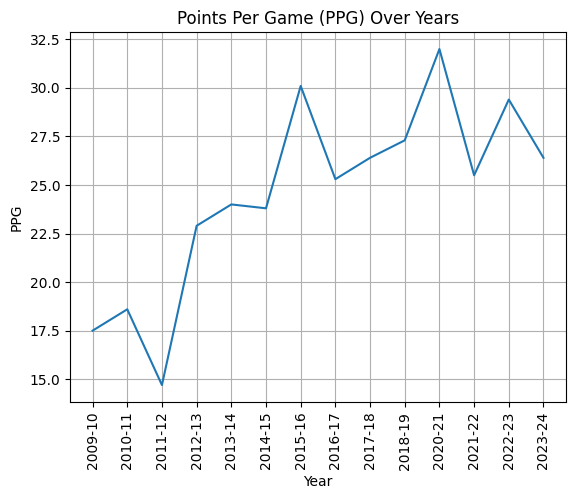

```python
# don't want the "Career" row
steph_df.drop(index=15, inplace=True)

plt.plot(steph_df['Season'], steph_df['PTS'])
plt.title('Points Per Game (PPG) Over Years')
plt.xlabel('Year')
plt.ylabel('PPG')

# rotate ticks to make them readable
plt.xticks(rotation=90)

plt.grid(True)
plt.show()
```

What conclusions can we reach based off of this graph? First off, the distribution seems a little volatile. There is a general increasing trend, but within that trend, there are pronounced peaks and valleys. Furthermore, while the scale of the graph might throw you off a bit, it is important to note that Curry has been a 25-ppg or more scorer for the past decade. Thus, while there is volatility within that range, he is consistently at or above that mark.

### Graphs 2 and 3: Stephen Curry's Efficiency Over Time

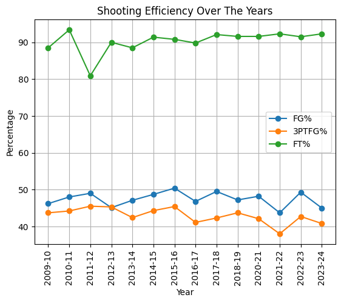

```python
# multiplying by 100 to convert from decimal to percentage
plt.plot(steph_df['Season'], steph_df['FG%'] * 100, label='FG%', marker='o', linestyle='-')
plt.plot(steph_df['Season'], steph_df['3P%'] * 100, label='3PTFG%', marker='o', linestyle='-')
plt.plot(steph_df['Season'], steph_df['FT%'] * 100, label='FT%', marker='o', linestyle='-')

plt.title('Shooting Efficiency Over The Years')
plt.xlabel('Year')
plt.ylabel('Percentage')
plt.xticks(rotation=90)

# Show legend with labels
plt.legend()

plt.grid(True)
plt.show()
```

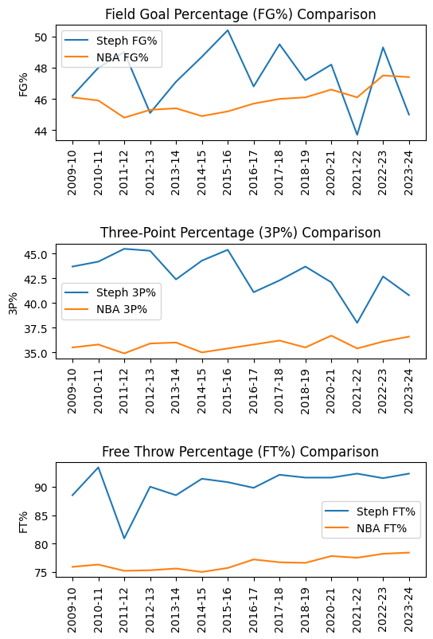

```python
league_efficiency = pd.DataFrame()

# create league efficiency dataframe with data gathered from Basketball Reference
league_efficiency['FG%'] = [0.461, 0.459, 0.448, 0.453, 0.454, 0.449, 0.452, 0.457, 0.460, 0.461, 0.466, 0.461, 0.475, 0.474]
league_efficiency['3P%'] = [0.355, 0.358, 0.349, 0.359, 0.360, 0.350, 0.354, 0.358, 0.362, 0.355, 0.367, 0.354, 0.361, 0.366]
league_efficiency['FT%'] = [0.759, 0.763, 0.752, 0.753, 0.756, 0.750, 0.757, 0.772, 0.767, 0.766, 0.778, 0.775, 0.782, 0.784]

# want three different plots comparing each efficiency category between Curry and the rest of the league
fig, axes = plt.subplots(3, 1, figsize=(6, 9), gridspec_kw={'hspace': 0.9})

# this one has year on the x-axis and FG% on the y-axis
axes[0].plot(steph_df['Season'], steph_df['FG%'] * 100, label='Steph FG%')
axes[0].plot(steph_df['Season'], league_efficiency['FG%'] * 100, label='NBA FG%')
axes[0].set_title('Field Goal Percentage (FG%) Comparison')
axes[0].set_ylabel('FG%')
axes[0].legend()

# this one has year on the x-axis and 3P% on the y-axis
axes[1].plot(steph_df['Season'], steph_df['3P%'] * 100, label='Steph 3P%')
axes[1].plot(steph_df['Season'], league_efficiency['3P%'] * 100, label='NBA 3P%')
axes[1].set_title('Three-Point Percentage (3P%) Comparison')
axes[1].set_ylabel('3P%')
axes[1].legend()

# this one has year on the x-axis and FT% on the y-axis
axes[2].plot(steph_df['Season'], steph_df['FT%'] * 100, label='Steph FT%')
axes[2].plot(steph_df['Season'], league_efficiency['FT%'] * 100, label='NBA FT%')
axes[2].set_title('Free Throw Percentage (FT%) Comparison')
axes[2].set_ylabel('FT%')
axes[2].legend()

# set x-ticks for each graph and rotate so they're readable
for ax in axes:
    ax.set_xticks(steph_df['Season'])
    ax.set_xticklabels(steph_df['Season'], rotation=90)
```

### Graph 4: Taking a Look at Curry's Advanced Stats

There are a lot of advanced stats we can look at, but for this specific graph, we will be analyzing Curry's Value Over Replacement Player (VORP). If you would like to dive deep into the math behind the stat, you can follow this [link](https://hackastat.eu/en/learn-a-stat-box-plus-minus-and-vorp/), but I will explain the basics here. VORP basically measures how good a player is relative to a "replacement player" with a baseline score of 0. It uses other metrics like [Box Plus-Minus (BPM)](https://www.basketball-reference.com/about/bpm2.html) to capture in one metric how much better a player is relative to competition. The higher a player's VORP, the more valuable they are compared to a baseline role-player.

To give a sense of scale, a VORP of +4.0 is an All-Star season, +6.0 is All-NBA, +8.0 is a peak MVP season, and +10.0 is an all-time historic season.

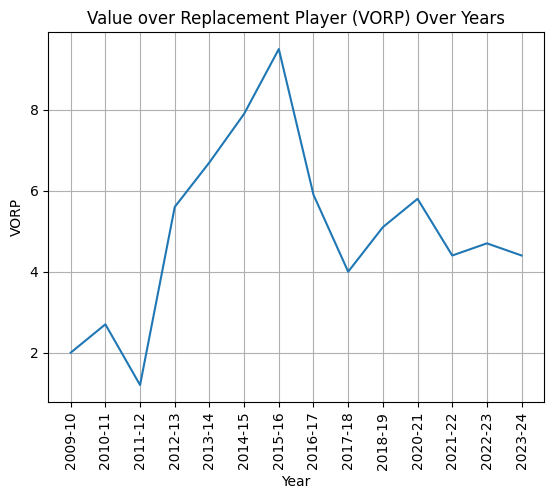

```python
plt.plot(steph_advanced['Season'], steph_advanced['VORP'])
plt.title('Value over Replacement Player (VORP) Over Years')
plt.xlabel('Year')
plt.ylabel('VORP')

# rotate ticks to make them readable
plt.xticks(rotation=90)

plt.grid(True)
plt.show()
```

From this graph, we see that Curry, from basically his fourth season onward, has consistently been an All-Star level player at worst. For the next 4-5 years beyond that, he was offering All-NBA to historic levels of value, and while he has not cleared 6.0 since 2016-17, he has still been offering close to perennial All-NBA level production.

Now, let's take a look at the other players around Stephen Curry.

### Graph 5: Combined PPG of Other Players

```python
# function that aggregates the total points across the 4 other players based on year
def total_ppg_for_year(df, year):
    total = df[df['year'] == year]['PTS'].sum()
    return total

combined_ppg_of_others = pd.DataFrame()

years = [2015, 2016, 2017, 2018, 2019, 2021, 2022, 2023, 2024]

# create empty list to append total pts based on year to
total_ppg = []

combined_ppg_of_others['Year'] = years

for year in years:
    # calls function and appends result to list
    total_ppg.append(total_ppg_for_year(others, year))

# make updated list a column in df
combined_ppg_of_others["Combined PTS"] = total_ppg

combined_ppg_of_others
```

|  | Year | Combined PTS |
| --- | --- | --- |
| 0 | 2015 | 51.3 |
| 1 | 2016 | 54.8 |
| 2 | 2017 | 65.2 |
| 3 | 2018 | 63.4 |
| 4 | 2019 | 71.2 |
| 5 | 2021 | 52.5 |
| 6 | 2022 | 63.6 |
| 7 | 2023 | 67.9 |
| 8 | 2024 | 48.9 |

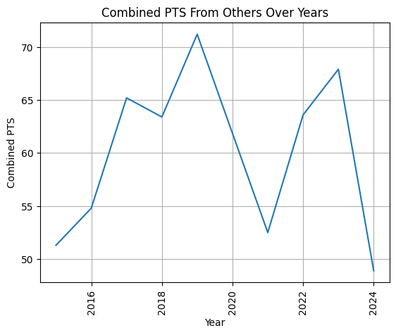

```python
plt.plot(combined_ppg_of_others['Year'], combined_ppg_of_others['Combined PTS'])
plt.title('Combined PTS From Others Over Years')
plt.xlabel('Year')
plt.ylabel('Combined PTS')

# rotate ticks to make them readable
plt.xticks(rotation=90)

plt.grid(True)
plt.show()
```

One thing we can clearly see from this graph is that there was a steep drop in "help" PTS in 2024 compared to 2023 by almost 20 points. This is concerning because as a player gets older, you need to surround them with more help to cover for any loss in efficiency, defense, or scoring due to age, but the opposite is happening in Golden State. Steph is not immune to natural decline due to age, so this will be something to monitor over the next year or two.

### Graph 6: Combined Accolades of Other Players

```python
# If a player was an All-Star while they were playing with Curry, they get a "Yes" for that column in that year. Otherwise "No".
# data taken from official NBA website
# note: for 2024, it is projected that no Warriors teammate will make an All NBA or All Defensive team
others["All Star"] = ["Yes", "No", "No", "No", "Yes", "Yes", "No", "No", "Yes", "Yes", "Yes", "No", "Yes", "Yes", "Yes", "No", "Yes", "Yes", "No", "No", "No", "No", "No", "No", "Yes", "No", "No", "Yes", "No", "No", "No", "No", "No", "No", "No", "No"]
others["All NBA or All Defense"] = ["Yes", "Yes", "No", "No", "Yes", "Yes", "No", "No", "No", "Yes", "Yes", "No", "No", "Yes", "Yes", "No", "Yes", "Yes", "Yes", "No", "No", "Yes", "No", "No", "No", "No", "No", "Yes", "No", "No", "Yes", "No", "No", "No", "No", "No"]
```

```python
# group all the All-Stars by year and count how many there are
all_star_counts = others[others['All Star'] == 'Yes'].groupby('year')['All Star'].count().reset_index()
all_star_counts
```

|  | year | All Star |
| --- | --- | --- |
| 0 | 2015 | 1 |
| 1 | 2016 | 2 |
| 2 | 2017 | 3 |
| 3 | 2018 | 3 |
| 4 | 2019 | 2 |
| 5 | 2022 | 2 |

There are some years where Curry had no all-star teammates, so we will add those 0s in manually.

```python
all_stars = pd.DataFrame()

all_stars['year'] = [2015, 2016, 2017, 2018, 2019, 2021, 2022, 2023]
all_stars['All Star'] = [1, 2, 3, 3, 2, 0, 2, 0]

all_stars
```

|  | year | All Star |
| --- | --- | --- |
| 0 | 2015 | 1 |
| 1 | 2016 | 2 |
| 2 | 2017 | 3 |
| 3 | 2018 | 3 |
| 4 | 2019 | 2 |
| 5 | 2021 | 0 |
| 6 | 2022 | 2 |
| 7 | 2023 | 0 |

```python
# same way as above
all_nba_or_defense_counts = others[others['All NBA or All Defense'] == 'Yes'].groupby('year')['All NBA or All Defense'].count().reset_index()
all_nba_or_defense_counts
```

|  | year | All NBA or All Defense |
| --- | --- | --- |
| 0 | 2015 | 2 |
| 1 | 2016 | 2 |
| 2 | 2017 | 2 |
| 3 | 2018 | 2 |
| 4 | 2019 | 3 |
| 5 | 2021 | 1 |
| 6 | 2022 | 1 |
| 7 | 2023 | 1 |

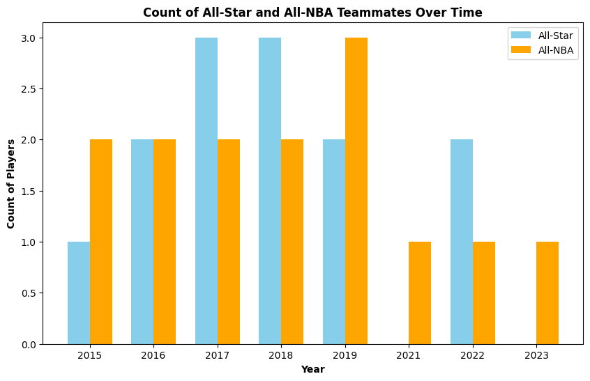

```python
# Plotting
plt.figure(figsize=(10, 6))

# Bar width
bar_width = 0.35

# Set position of bar on X axis
r1 = range(len(all_stars['year']))
r2 = [x + bar_width for x in r1]

# Plotting bars for All-Star
plt.bar(r1, all_stars['All Star'], color='skyblue', width=bar_width, label='All-Star')

# Plotting bars for All-NBA
plt.bar(r2, all_nba_or_defense_counts['All NBA or All Defense'], color='orange', width=bar_width, label='All-NBA')

# Adding labels
plt.xlabel('Year', fontweight='bold')
plt.ylabel('Count of Players', fontweight='bold')
plt.title('Count of All-Star and All-NBA Teammates Over Time', fontweight='bold')
plt.xticks([r + bar_width / 2 for r in range(len(all_stars['year']))], all_stars['year'])

# Adding legend
plt.legend()

plt.show()
```

The scale of this graph might throw conclusions off a bit, but it is clear to see that Curry is not working with the same level of talent in the 2020s as he had in the late 2010s.

### Graphs 7 and 8: Comparing Golden State's Offensive/Defensive Rating with the Rest of the NBA

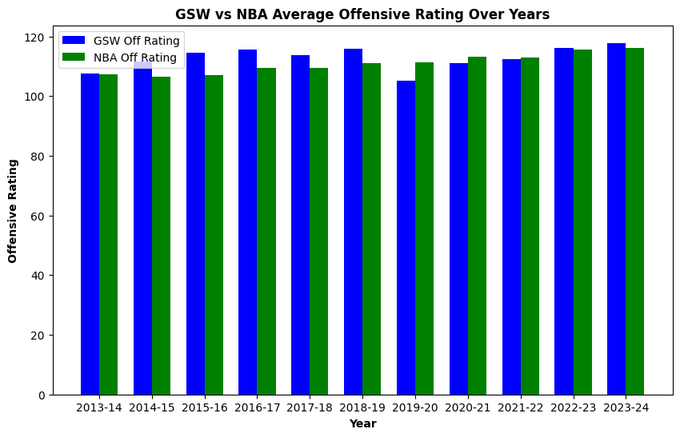

```python
plt.figure(figsize=(10, 6))

bar_width = 0.35

# Set position of bar on X axis
r1 = range(len(gsw_off_def_rating['Season']))
r2 = [x + bar_width for x in r1]

# Plotting bars
plt.bar(r1, gsw_off_def_rating['GSW_Off_Rating'], color='blue', width=bar_width, label='GSW Off Rating')
plt.bar(r2, gsw_off_def_rating['NBA_Off_Rating'], color='green', width=bar_width, label='NBA Off Rating')

# Adding labels
plt.xlabel('Year', fontweight='bold')
plt.ylabel('Offensive Rating', fontweight='bold')
plt.title('GSW vs NBA Average Offensive Rating Over Years', fontweight='bold')

# put ticks in middle of bars
plt.xticks([r + bar_width / 2 for r in range(len(gsw_off_def_rating['Season']))], gsw_off_def_rating['Season'])

plt.legend()

plt.show()
```

What conclusions can we draw from this graph? Well, first off, by virtue of keeping the 2013-14 data, we can see that the coaching change proved very fruitful as Golden State went from being around league average in offensive rating to about 5 points better, largely maintaining the same roster across both years. Steve Kerr's coaching acumen proved itself throughout the course of the next decade, as Golden State outperformed the rest of the league in offensive rating by a healthy margin, and the only years where this didn't happen was when the roster suffered massive injuries to key contributors. Even then, the offense performed better than one might expect without its best players.

Let's do the same thing for defensive rating.

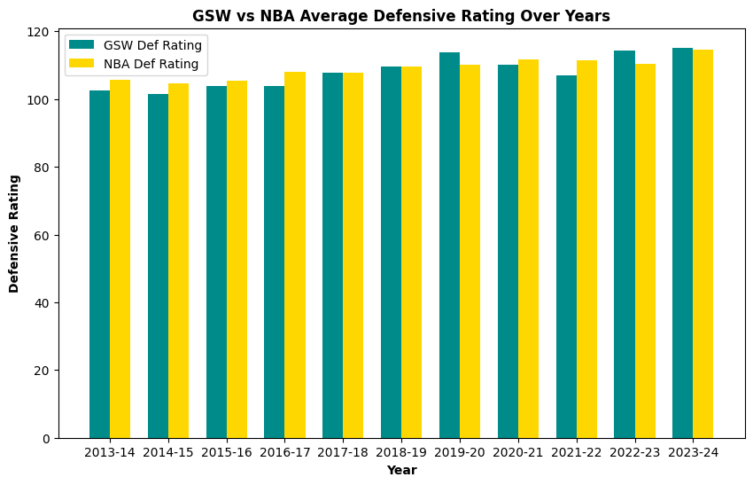

```python
plt.figure(figsize=(10, 6))

bar_width = 0.35

# Set position of bar on X axis
r1 = range(len(gsw_off_def_rating['Season']))
r2 = [x + bar_width for x in r1]

# Plotting bars
plt.bar(r1, gsw_off_def_rating['GSW_Def_Rating'], color='darkcyan', width=bar_width, label='GSW Def Rating')
plt.bar(r2, gsw_off_def_rating['NBA_Def_Rating'], color='gold', width=bar_width, label='NBA Def Rating')

# Adding labels
plt.xlabel('Year', fontweight='bold')
plt.ylabel('Defensive Rating', fontweight='bold')
plt.title('GSW vs NBA Average Defensive Rating Over Years', fontweight='bold')

# put ticks in middle of bars
plt.xticks([r + bar_width / 2 for r in range(len(gsw_off_def_rating['Season']))], gsw_off_def_rating['Season'])

plt.legend()

plt.show()
```

From this, we see that Coach Kerr continued the previous coach's views on defense by keeping his team better than league average save for a couple years. One worrying thing to note, however, is that the team has been worse than league average each of the last two years. Whether that is on the schemes or the age of the roster remains to be seen, but it is clear that Coach Kerr has to tinker with the defensive plans if he wants to reverse this trend.

## Analysis, Hypothesis Testing, and ML

### Hypothesis Test 1: Does Stephen Curry's scoring output have an effect on wins?

Considering that Stephen Curry is the engine of the Warriors dynasty, it would logically follow that his performance has an impact on how the team does overall. Let's test this with a hypothesis test.

Here are the null and alternate hypotheses:

H0: There is no relationship between Stephen Curry's Points per Game (PPG) and the number of wins.

H1: There is a relationship between Stephen Curry's Points per Game (PPG) and the number of wins.

First, let's add a column of wins to the dataframe.

```python
# data obtained from official NBA website
steph_df['Wins'] = [26, 36, 23, 47, 51, 67, 73, 67, 58, 57, 39, 53, 44, 46]
steph_df
```

|  | Season | Age | Tm | Lg | Pos | G | GS | MP | FG | FGA | ... | DRB | TRB | AST | STL | BLK | TOV | PF | PTS | Awards | Wins |
| --- | --- | --- | --- | --- | --- | --- | --- | --- | --- | --- | --- | --- | --- | --- | --- | --- | --- | --- | --- | --- | --- |
| 0 | 2009-10 | 21.0 | GSW | NBA | PG | 80 | 77 | 36.2 | 6.6 | 14.3 | ... | 3.9 | 4.5 | 5.9 | 1.9 | 0.2 | 3.0 | 3.2 | 17.5 | ROY-2 | 26 |
| 1 | 2010-11 | 22.0 | GSW | NBA | PG | 74 | 74 | 33.6 | 6.8 | 14.2 | ... | 3.2 | 3.9 | 5.8 | 1.5 | 0.3 | 3.1 | 3.1 | 18.6 | NaN | 36 |
| 2 | 2011-12 | 23.0 | GSW | NBA | PG | 26 | 23 | 28.2 | 5.6 | 11.4 | ... | 2.8 | 3.4 | 5.3 | 1.5 | 0.3 | 2.5 | 2.4 | 14.7 | NaN | 23 |
| 3 | 2012-13 | 24.0 | GSW | NBA | PG | 78 | 78 | 38.2 | 8.0 | 17.8 | ... | 3.3 | 4.0 | 6.9 | 1.6 | 0.2 | 3.1 | 2.5 | 22.9 | MVP-11MIP-8 | 47 |
| 4 | 2013-14 | 25.0 | GSW | NBA | PG | 78 | 78 | 36.5 | 8.4 | 17.7 | ... | 3.7 | 4.3 | 8.5 | 1.6 | 0.2 | 3.8 | 2.5 | 24.0 | MVP-6NBA2AS | 51 |
| 5 | 2014-15 | 26.0 | GSW | NBA | PG | 80 | 80 | 32.7 | 8.2 | 16.8 | ... | 3.6 | 4.3 | 7.7 | 2.0 | 0.2 | 3.1 | 2.0 | 23.8 | MVP-1NBA1AS | 67 |
| 6 | 2015-16 | 27.0 | GSW | NBA | PG | 79 | 79 | 34.2 | 10.2 | 20.2 | ... | 4.6 | 5.4 | 6.7 | 2.1 | 0.2 | 3.3 | 2.0 | 30.1 | MVP-1NBA1ASMIP-4 | 73 |
| 7 | 2016-17 | 28.0 | GSW | NBA | PG | 79 | 79 | 33.4 | 8.5 | 18.3 | ... | 3.7 | 4.5 | 6.6 | 1.8 | 0.2 | 3.0 | 2.3 | 25.3 | MVP-6NBA2AS | 67 |
| 8 | 2017-18 | 29.0 | GSW | NBA | PG | 51 | 51 | 32.0 | 8.4 | 16.9 | ... | 4.4 | 5.1 | 6.1 | 1.6 | 0.2 | 3.0 | 2.2 | 26.4 | MVP-10NBA3AS | 58 |
| 9 | 2018-19 | 30.0 | GSW | NBA | PG | 69 | 69 | 33.8 | 9.2 | 19.4 | ... | 4.7 | 5.3 | 5.2 | 1.3 | 0.4 | 2.8 | 2.4 | 27.3 | MVP-5NBA1AS | 57 |
| 11 | 2020-21 | 32.0 | GSW | NBA | PG | 63 | 63 | 34.2 | 10.4 | 21.7 | ... | 5.0 | 5.5 | 5.8 | 1.2 | 0.1 | 3.4 | 1.9 | 32.0 | MVP-3NBA1AS | 39 |
| 12 | 2021-22 | 33.0 | GSW | NBA | PG | 64 | 64 | 34.5 | 8.4 | 19.1 | ... | 4.7 | 5.2 | 6.3 | 1.3 | 0.4 | 3.2 | 2.0 | 25.5 | MVP-8NBA2AS | 53 |
| 13 | 2022-23 | 34.0 | GSW | NBA | PG | 56 | 56 | 34.7 | 10.0 | 20.2 | ... | 5.4 | 6.1 | 6.3 | 0.9 | 0.4 | 3.2 | 2.1 | 29.4 | MVP-9NBA2ASCPOY-9 | 44 |
| 14 | 2023-24 | 35.0 | GSW | NBA | PG | 74 | 74 | 32.7 | 8.8 | 19.5 | ... | 4.0 | 4.5 | 5.1 | 0.7 | 0.4 | 2.8 | 1.6 | 26.4 | AS | 46 |

14 rows × 32 columns

Now, let's run an ordinary least squares (OLS) regression between PTS and Wins to examine the significance of this relationship.

```python
import statsmodels.formula.api as smf
```

```python
ols_results = smf.ols(formula="Wins ~ PTS", data=steph_df).fit()
print(ols_results.summary())
```

```
                            OLS Regression Results
==============================================================================
Dep. Variable:                   Wins   R-squared:                       0.359
Model:                            OLS   Adj. R-squared:                  0.305
Method:                 Least Squares   F-statistic:                     6.708
Date:                Mon, 13 May 2024   Prob (F-statistic):             0.0237
Time:                        20:03:22   Log-Likelihood:                -54.093
No. Observations:                  14   AIC:                             112.2
Df Residuals:                      12   BIC:                             113.5
Df Model:                           1
Covariance Type:            nonrobust
==============================================================================
                 coef    std err          t      P>|t|      [0.025      0.975]
------------------------------------------------------------------------------
Intercept      4.1778     17.650      0.237      0.817     -34.279      42.635
PTS            1.8276      0.706      2.590      0.024       0.290       3.365
==============================================================================
Omnibus:                        0.092   Durbin-Watson:                   1.242
Prob(Omnibus):                  0.955   Jarque-Bera (JB):                0.191
Skew:                          -0.146   Prob(JB):                        0.909
Kurtosis:                       2.507   Cond. No.                         133.
==============================================================================

Notes:
[1] Standard Errors assume that the covariance matrix of the errors is correctly specified.
```

According to the results of the OLS regression, we see that the p-value is 0.024. Comparing this to a 0.05 alpha value, it is less than the significance level, meaning that the relationship between Curry's PTS and GSW Wins IS statistically significant, and we reject the null hypothesis. This shows that it is important to do statistical analysis to confirm conclusions that may seem intuitive.

### ML Model 1 (Multivariate Regression): Modeling Stephen Curry's Effect on Wins

Let's try and create a multivariate regression model taking in the features we explored in the EDA section and predict the number of wins the Warriors had in a season.

Below, we will store our features in X and our target in y. We will use scikit-learn's train_test_split to randomly split the data into 90-10 training and testing data. This is because we have a small data set; ideally, your testing set would be bigger.

```python
from sklearn.model_selection import train_test_split
from sklearn.linear_model import LinearRegression
from sklearn.metrics import mean_squared_error
```

```python
steph_df.columns
```

```
Index(['Season', 'Age', 'Tm', 'Lg', 'Pos', 'G', 'GS', 'MP', 'FG', 'FGA', 'FG%',
       '3P', '3PA', '3P%', '2P', '2PA', '2P%', 'eFG%', 'FT', 'FTA', 'FT%',
       'ORB', 'DRB', 'TRB', 'AST', 'STL', 'BLK', 'TOV', 'PF', 'PTS', 'Awards',
       'Wins'],
      dtype='object')
```

```python
# three most ubiquitous stats in basketball: points, assists, and rebounds
X = steph_df[['PTS', 'AST', 'TRB']]
y = steph_df['Wins']

X_train, X_test, y_train, y_test = train_test_split(X, y, test_size=0.1, random_state=1)
model1 = LinearRegression()
model1.fit(X_train, y_train)

print(f'PTS coefficient: {model1.coef_[0]}')
print(f'AST coefficient: {model1.coef_[1]}')
print(f'REB coefficient: {model1.coef_[2]}')
print(f'Intercept: {model1.intercept_}')
```

```
PTS coefficient: 2.3446493918638347
AST coefficient: 5.501400692341443
REB coefficient: -5.280206083522313
Intercept: -18.971300590792396
```

```python
y_pred = model1.predict(X_test)

mse = mean_squared_error(y_test, y_pred)
print("MSE: " + str(mse))
```

```
MSE: 109.84914378713306
```

```python
ols_results = smf.ols(formula="Wins ~ PTS + AST + TRB", data=steph_df).fit()
print(ols_results.summary())
```

```
                            OLS Regression Results
==============================================================================
Dep. Variable:                   Wins   R-squared:                       0.542
Model:                            OLS   Adj. R-squared:                  0.405
Method:                 Least Squares   F-statistic:                     3.945
Date:                Mon, 13 May 2024   Prob (F-statistic):             0.0428
Time:                        20:03:22   Log-Likelihood:                -51.734
No. Observations:                  14   AIC:                             111.5
Df Residuals:                      10   BIC:                             114.0
Df Model:                           3
Covariance Type:            nonrobust
==============================================================================
                 coef    std err          t      P>|t|      [0.025      0.975]
------------------------------------------------------------------------------
Intercept    -17.9619     32.214     -0.558      0.589     -89.739      53.815
PTS            2.5308      1.268      1.996      0.074      -0.294       5.355
AST            5.4764      3.534      1.550      0.152      -2.398      13.351
TRB           -6.2864      8.380     -0.750      0.470     -24.958      12.385
==============================================================================
Omnibus:                        0.651   Durbin-Watson:                   1.837
Prob(Omnibus):                  0.722   Jarque-Bera (JB):                0.604
Skew:                          -0.409   Prob(JB):                        0.739
Kurtosis:                       2.395   Cond. No.                         279.
==============================================================================

Notes:
[1] Standard Errors assume that the covariance matrix of the errors is correctly specified.
```

First off, our MSE is approximately 110, which isn't great because it implies that, on average, we're +/- 10.5 Wins away from the true number. Furthermore, our r-squared value is 0.542, meaning our current group of independent variables account for only 54.2% of the variance in Wins. Let's see if we can do better by adding some more variables.

```python
# adding games played, turnovers, and field goals made
X = steph_df[['PTS', 'AST', 'TRB', 'G', 'TOV', 'FG']]
y = steph_df['Wins']

X_train, X_test, y_train, y_test = train_test_split(X, y, test_size=0.1, random_state=1)
model2 = LinearRegression()
model2.fit(X_train, y_train)

print(f'PTS coefficient: {model2.coef_[0]}')
print(f'AST coefficient: {model2.coef_[1]}')
print(f'REB coefficient: {model2.coef_[2]}')
print(f'Games Played coefficient: {model2.coef_[3]}')
print(f'Turnovers coefficient: {model2.coef_[4]}')
print(f'Field Goals made coefficient: {model2.coef_[5]}')
print(f'Intercept: {model2.intercept_}')
```

```
PTS coefficient: 5.9062633737459285
AST coefficient: 14.597104498368072
REB coefficient: -0.35140357379780746
Games Played coefficient: 0.3514650244813478
Turnovers coefficient: -42.46959941830946
Field Goals made coefficient: -12.384283842506894
Intercept: 25.66153807206054
```

```python
y_pred = model2.predict(X_test)

mse = mean_squared_error(y_test, y_pred)
print("MSE: " + str(mse))
```

```
MSE: 51.26151314214206
```

```python
ols_results = smf.ols(formula="Wins ~ PTS + AST + TRB + G + TOV + FG", data=steph_df).fit()
print(ols_results.summary())
```

```
                            OLS Regression Results
==============================================================================
Dep. Variable:                   Wins   R-squared:                       0.819
Model:                            OLS   Adj. R-squared:                  0.664
Method:                 Least Squares   F-statistic:                     5.284
Date:                Mon, 13 May 2024   Prob (F-statistic):             0.0230
Time:                        20:03:22   Log-Likelihood:                -45.231
No. Observations:                  14   AIC:                             104.5
Df Residuals:                       7   BIC:                             108.9
Df Model:                           6
Covariance Type:            nonrobust
==============================================================================
                 coef    std err          t      P>|t|      [0.025      0.975]
------------------------------------------------------------------------------
Intercept     23.3950     28.981      0.807      0.446     -45.134      91.923
PTS            6.2564      3.529      1.773      0.120      -2.089      14.601
AST           14.3151      4.390      3.261      0.014       3.936      24.695
TRB            1.6992      6.843      0.248      0.811     -14.482      17.880
G              0.3467      0.196      1.766      0.121      -0.118       0.811
TOV          -41.5645     14.856     -2.798      0.027     -76.694      -6.435
FG           -14.4410     13.404     -1.077      0.317     -46.137      17.255
==============================================================================
Omnibus:                        0.782   Durbin-Watson:                   2.208
Prob(Omnibus):                  0.676   Jarque-Bera (JB):                0.694
Skew:                           0.448   Prob(JB):                        0.707
Kurtosis:                       2.378   Cond. No.                         969.
==============================================================================

Notes:
[1] Standard Errors assume that the covariance matrix of the errors is correctly specified.
```